# 49 | 桥接模式：如何实现支持不同类型和渠道的消息推送系统？

[figure not shown]

# 49 | 桥接模式：如何实现支持不同类型和渠道的消息推送系统？

2020-02-24 王争

设计模式之美

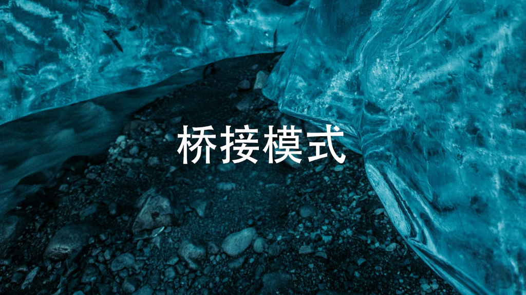

### 讲述：冯永吉

[interactive chart not shown]

上一节课我们学习了第一种结构型模式：代理模式。它在不改变原始类（或者叫被代理类）代码的情况下，通过引入代理类来给原始类附加功能。代理模式在平时的开发经常被用到，常用在业务系统中开发一些非功能性需求，比如：监控、统计、鉴权、限流、事务、幂等、日志。

今天，我们再学习另外一种结构型模式：桥接模式。桥接模式的代码实现非常简单，但是理解起来稍微有点难度，并且应用场景也比较局限，所以，相当于代理模式来说，桥接模式在实际的项目中并没有那么常用，你只需要简单了解，见到能认识就可以，并不是我们学习的重点。

话不多说，让我们正式开始今天的学习吧！

## 桥接模式的原理解析

桥接模式，也叫作桥梁模式，英文是 Bridge Design Pattern。这个模式可以说是 23 种设计模式中最难理解的模式之一了。我查阅了比较多的书籍和资料之后发现，对于这个模式有两种不同的理解方式。

当然，这其中“最纯正”的理解方式，当属 GoF 的《设计模式》一书中对桥接模式的定义。毕竟，这 23 种经典的设计模式，最初就是由这本书总结出来的。在 GoF 的《设计模式》一书中，桥接模式是这么定义的：“Decouple an abstraction from its implementation so that the two can vary independently。”翻译成中文就是：“将抽象和实现解耦，让它们可以独立变化。”

关于桥接模式，很多书籍、资料中，还有另外一种理解方式：“一个类存在两个（或多个）独立变化的维度，我们通过组合的方式，让这两个（或多个）维度可以独立进行扩展。”通过组合关系来替代继承关系，避免继承层次的指数级爆炸。这种理解方式非常类似于，我们之前讲过的“组合优于继承”设计原则，所以，这里我就不多解释了。我们重点看下 GoF 的理解方式。

GoF 给出的定义非常的简短，单凭这一句话，估计没几个人能看懂是什么意思。所以，我们通过 JDBC 驱动的例子来解释一下。JDBC 驱动是桥接模式的经典应用。我们先来看一下，如何利用 JDBC 驱动来查询数据库。具体的代码如下所示：

Class.forName("com.mysql.jdbc.Driver");//加载及注册JDBC驱动程序

String url = "jdbc:mysql://localhost:3306/sample_db?user=root&password=your_password";

Connection con = DriverManager.getConnection(url);

Statement stmt = con.createStatement()；

String query = "select * from test";

ResultSet rs=stmt.executeQuery(query);

while(rs.next()) {

rs.getString(1);

rs.getInt(2);

}

如果我们想要把 MySQL 数据库换成 Oracle 数据库，只需要把第一行代码中的 com.mysql.jdbc.Driver 换成 oracle.jdbc.driver.OracleDriver 就可以了。当然，也有更灵活的实现方式，我们可以把需要加载的 Driver 类写到配置文件中，当程序启动的时候，自动从配置文件中加载，这样在切换数据库的时候，我们都不需要修改代码，只需要修改配置文件就可以了。

不管是改代码还是改配置，在项目中，从一个数据库切换到另一种数据库，都只需要改动很少的代码，或者完全不需要改动代码，那如此优雅的数据库切换是如何实现的呢？

源码之下无秘密。要弄清楚这个问题，我们先从 com.mysql.jdbc.Driver 这个类的代码看起。我摘抄了部分相关代码，放到了这里，你可以看一下。

package com.mysql.jdbc;

import java.sql.SQLException;

public class Driver extends NonRegisteringDriver implements java.sql.Driver {

static {

try {

java.sql.DriverManager.registerDriver(new Driver());

} catch (SQLException E) {

throw new RuntimeException("Can't register driver!");

}

}

/**

* Construct a new driver and register it with DriverManager

* @throws SQLException if a database error occurs.

*/

public Driver() throws SQLException {

// Required for Class.forName().newInstance()

}

}

结合 com.mysql.jdbc.Driver 的代码实现，我们可以发现，当执行 Class.forName(“com.mysql.jdbc.Driver”) 这条语句的时候，实际上是做了两件事情。第一件事情是要求 JVM 查找并加载指定的 Driver 类，第二件事情是执行该类的静态代码，也就是将 MySQL Driver 注册到 DriverManager 类中。

现在，我们再来看一下，DriverManager 类是干什么用的。具体的代码如下所示。当我们把具体的 Driver 实现类（比如，com.mysql.jdbc.Driver）注册到 DriverManager 之后，后续所有对 JDBC 接口的调用，都会委派到对具体的 Driver 实现类来执行。而 Driver 实现类都实现了相同的接口（java.sql.Driver ），这也是可以灵活切换 Driver 的原因。

public class DriverManager {

private final static CopyOnWriteArrayList<DriverInfo> registeredDrivers = new CopyOnWriteArrayList<DriverInfo>();

//...

static {

loadInitialDrivers();

println("JDBC DriverManager initialized");

}

//...

public static synchronized void registerDriver(java.sql.Driver driver) throws SQLException {

if (driver != null) {

registeredDrivers.addIfAbsent(new DriverInfo(driver));

} else {

throw new NullPointerException();

}

}

public static Connection getConnection(String url, String user, String password) throws SQLException {

java.util.Properties info = new java.util.Properties();

if (user != null) {

info.put("user", user);

}

if (password != null) {

info.put("password", password);

}

return (getConnection(url, info, Reflection.getCallerClass()));

}

//...

}

桥接模式的定义是“将抽象和实现解耦，让它们可以独立变化”。那弄懂定义中“抽象”和“实现”两个概念，就是理解桥接模式的关键。那在 JDBC 这个例子中，什么是“抽象”？什么是“实现”呢？

实际上，JDBC 本身就相当于“抽象”。注意，这里所说的“抽象”，指的并非“抽象类”或“接口”，而是跟具体的数据库无关的、被抽象出来的一套“类库”。具体的 Driver（比如，com.mysql.jdbc.Driver）就相当于“实现”。注意，这里所说的“实现”，也并非指“接口的实现类”，而是跟具体数据库相关的一套“类库”。JDBC 和 Driver 独立开发，通过对象之间的组合关系，组装在一起。JDBC 的所有逻辑操作，最终都委托给 Driver 来执行。

我画了一张图帮助你理解，你可以结合着我刚才的讲解一块看。

[figure not shown]

## 桥接模式的应用举例

在第 16 节中，我们讲过一个 API 接口监控告警的例子：根据不同的告警规则，触发不同类型的告警。告警支持多种通知渠道，包括：邮件、短信、微信、自动语音电话。通知的紧急程度有多种类型，包括：SEVERE（严重）、URGENCY（紧急）、NORMAL（普通）、TRIVIAL（无关紧要）。不同的紧急程度对应不同的通知渠道。比如，SERVE（严重）级别的消息会通过“自动语音电话”告知相关人员。

在当时的代码实现中，关于发送告警信息那部分代码，我们只给出了粗略的设计，现在我们来一块实现一下。我们先来看最简单、最直接的一种实现方式。代码如下所示：

public enum NotificationEmergencyLevel {

SEVERE, URGENCY, NORMAL, TRIVIAL

}

public class Notification {

private List<String> emailAddresses;

private List<String> telephones;

private List<String> wechatIds;

public Notification() {}

public void setEmailAddress(List<String> emailAddress) {

this.emailAddresses = emailAddress;

}

public void setTelephones(List<String> telephones) {

this.telephones = telephones;

}

public void setWechatIds(List<String> wechatIds) {

this.wechatIds = wechatIds;

}

public void notify(NotificationEmergencyLevel level, String message) {

if (level.equals(NotificationEmergencyLevel.SEVERE)) {

//...自动语音电话

} else if (level.equals(NotificationEmergencyLevel.URGENCY)) {

//...发微信

} else if (level.equals(NotificationEmergencyLevel.NORMAL)) {

//...发邮件

} else if (level.equals(NotificationEmergencyLevel.TRIVIAL)) {

//...发邮件

}

}

}

//在API监控告警的例子中，我们如下方式来使用Notification类：

public class ErrorAlertHandler extends AlertHandler {

public ErrorAlertHandler(AlertRule rule, Notification notification){

super(rule, notification);

}

@Override

public void check(ApiStatInfo apiStatInfo) {

if (apiStatInfo.getErrorCount() > rule.getMatchedRule(apiStatInfo.getApi()).getMaxErrorCount()) {

notification.notify(NotificationEmergencyLevel.SEVERE, "...");

}

}

}

Notification 类的代码实现有一个最明显的问题，那就是有很多 if-else 分支逻辑。实际上，如果每个分支中的代码都不复杂，后期也没有无限膨胀的可能（增加更多 if-else 分支判断），那这样的设计问题并不大，没必要非得一定要摒弃 if-else 分支逻辑。

不过，Notification 的代码显然不符合这个条件。因为每个 if-else 分支中的代码逻辑都比较复杂，发送通知的所有逻辑都扎堆在 Notification 类中。我们知道，类的代码越多，就越难读懂，越难修改，维护的成本也就越高。很多设计模式都是试图将庞大的类拆分成更细小的类，然后再通过某种更合理的结构组装在一起。

针对 Notification 的代码，我们将不同渠道的发送逻辑剥离出来，形成独立的消息发送类（MsgSender 相关类）。其中，Notification 类相当于抽象，MsgSender 类相当于实现，两者可以独立开发，通过组合关系（也就是桥梁）任意组合在一起。所谓任意组合的意思就是，不同紧急程度的消息和发送渠道之间的对应关系，不是在代码中固定写死的，我们可以动态地去指定（比如，通过读取配置来获取对应关系）。

按照这个设计思路，我们对代码进行重构。重构之后的代码如下所示：

public interface MsgSender {

void send(String message);

}

public class TelephoneMsgSender implements MsgSender {

private List<String> telephones;

public TelephoneMsgSender(List<String> telephones) {

this.telephones = telephones;

}

@Override

public void send(String message) {

//...

}

}

public class EmailMsgSender implements MsgSender {

// 与TelephoneMsgSender代码结构类似，所以省略...

}

public class WechatMsgSender implements MsgSender {

// 与TelephoneMsgSender代码结构类似，所以省略...

}

public abstract class Notification {

protected MsgSender msgSender;

public Notification(MsgSender msgSender) {

this.msgSender = msgSender;

}

public abstract void notify(String message);

}

public class SevereNotification extends Notification {

public SevereNotification(MsgSender msgSender) {

super(msgSender);

}

@Override

public void notify(String message) {

msgSender.send(message);

}

}

public class UrgencyNotification extends Notification {

// 与SevereNotification代码结构类似，所以省略...

}

public class NormalNotification extends Notification {

// 与SevereNotification代码结构类似，所以省略...

}

public class TrivialNotification extends Notification {

// 与SevereNotification代码结构类似，所以省略...

}

## 重点回顾

好了，今天的内容到此就讲完了。我们一块来总结回顾一下，你需要重点掌握的内容。

总体上来讲，桥接模式的原理比较难理解，但代码实现相对简单。

对于这个模式有两种不同的理解方式。在 GoF 的《设计模式》一书中，桥接模式被定义为：“将抽象和实现解耦，让它们可以独立变化。”在其他资料和书籍中，还有另外一种更加简单的理解方式：“一个类存在两个（或多个）独立变化的维度，我们通过组合的方式，让这两个（或多个）维度可以独立进行扩展。”

对于第一种 GoF 的理解方式，弄懂定义中“抽象”和“实现”两个概念，是理解它的关键。定义中的“抽象”，指的并非“抽象类”或“接口”，而是被抽象出来的一套“类库”，它只包含骨架代码，真正的业务逻辑需要委派给定义中的“实现”来完成。而定义中的“实现”，也并非“接口的实现类”，而是的一套独立的“类库”。“抽象”和“实现”独立开发，通过对象之间的组合关系，组装在一起。

对于第二种理解方式，它非常类似我们之前讲过的“组合优于继承”设计原则，通过组合关系来替代继承关系，避免继承层次的指数级爆炸。

## 课堂讨论

在桥接模式的第二种理解方式的第一段代码实现中，Notification 类中的三个成员变量通过 set 方法来设置，但是这样的代码实现存在一个明显的问题，那就是 emailAddresses、telephones、wechatIds 中的数据有可能在 Notification 类外部被修改，那如何重构代码才能避免这种情况的发生呢？

public class Notification {

private List<String> emailAddresses;

private List<String> telephones;

private List<String> wechatIds;

public Notification() {}

public void setEmailAddress(List<String> emailAddress) {

this.emailAddresses = emailAddress;

}

public void setTelephones(List<String> telephones) {

this.telephones = telephones;

}

public void setWechatIds(List<String> wechatIds) {

this.wechatIds = wechatIds;

}

//...

}

欢迎留言和我分享你的思考和疑惑。如果有收获，也欢迎你把这篇文章分享给你的朋友。

[figure not shown]

## 精选留言(23)

[figure not shown]

- 下雨天

  2020-02-24

  课后题：可以考虑使用建造者模式来重构！参见46讲中  
  建造者使用场景：  
  1.构造方法必填属性很多，需要检验  
  2.类属性之间有依赖关系或者约束条件  
  3.创建不可变对象(此题刚好符合这种场景)

  展开**

  **

  ** 5

[figure not shown]

- 忆水寒

  2020-02-24

  参数不多的情况可以在构造函数初始化，如果参数较多 就可以使用建造者模式初始化。

  **

  ** 5

[figure not shown]

- 小晏子

  2020-02-24

  “emailAddresses、telephones、wechatIds 中的数据有可能在 Notification 类外部被修改”的原因是对外暴露了修改接口set*，如果不想被修改那么就不要暴露set接口，这样的话初始化这些email，telephone和wechat的工作就放到构造函数里，用构造函数去初始化这些变量，这样初始化之后正常情况下外面没法修改。

  展开**

  **

  ** 2

[figure not shown]

- 陈尧东

  2020-02-24

  老师，有个疑问，重构后SevereNotification类依赖的都是接口MessageSender，没有依赖具体的实现，哪其它几个XxxNotification实现与其有何区别？

  展开**

  ** 2

  ** 1

[figure not shown]

- 黄林晴

  2020-02-24

  打卡

  展开**

  **

  ** 1
- 每天晒白牙

  2020-02-24

  建造者模式

  展开**

  **

  ** 1

[figure not shown]

- 松花皮蛋me

  2020-02-24

  这个模式和策略模式的区别是？

  展开**

  **

  ** 1

[figure not shown]

- test

  2020-02-25

  返回不可变对象

  展开**

  **

  **
- 冰激凌的眼泪

  2020-02-25

  在桥接模式中，所谓抽象就是要干什么，所谓实现就是怎么去干，但是这俩是没有抽象与实现的意义的。

  **

  **

[figure not shown]

- 小兵

  2020-02-25

  最简单的是加一个非空判断，其次是在构造函数中赋值，这里并没有很复杂的逻辑，通过构造函数就可以了，如果逻辑复杂，可以考虑建造者模式。

  展开**

  **

  **

[figure not shown]

- sunnywhy

  2020-02-25

  课后题：首先去掉public的setter方法是必须的，然后可以用构造方法来初始化（没有太多参数的情况下，没有必要用builder模式）。另外，还要考虑是不是需要暴露getter方法，如果需要的话，可以返回一个不可修改的list（本文中list中的元素为String，所以不用担心单个元素被修改的情况，没有必要返回一个copy）

  展开**

  **

  **

[figure not shown]

- 平风造雨

  2020-02-25

  Builder模式隐藏目标对象的set方法，或者在set方法里深拷贝构建一个新的只读容器。

  **

  **

[figure not shown]

- Frank

  2020-02-24

  1. 桥接模式是将“抽象”和“实现”解耦，让它们可以独立变化。重点在于理解“抽象”和“实现”。这个模式理解难度挺大的。  
  2. 对于第二种理解“一个类存在两个（或多个）独立变化的维度，我们通过组合的方式，让这两个（或多个）维度可以独立进行扩展”不能理解清楚，一个类的不同维度怎么独立扩展？是像例子中的Notification类，抽离出发送渠道类，Notification演变成抽象，只定义需要子类实现的锲约。这样在物理上是变成两个类了。在逻辑上是不是可以理解成Notification的抽象和发送渠道实现在一定程度上是原先Notification类的不同维度的扩展？  
  对于课堂讨论我能想到将Notification 类的创建设计成建造者模式，使其不可变。

  展开**

  **

  **
- 李小四

  2020-02-24

  设计模式_49:  
  # 作业  
  使用Builder模式  
  # 感想  
  老实讲，桥接这个模式，我现在还是似懂非懂(也就是不懂)，文章已经看了3遍了，还看了*Head First*中的解读，依然不是很明白，我想又要慢慢来了，期待一段时间后的一声 “哦。。。”

  展开**

  **

  **

[figure not shown]

- 吴帆

  2020-02-24

  这个模式挺精妙的，不知道最终使用的时候是不是通过传入等级再反射来生成Notification的实现类，类似于JDBC的用法。这样确实可以完成抽象和实现的解耦，丢掉那些讨厌的if else语句

  **

  **

[figure not shown]

- 不似旧日

  2020-02-24

  简单的问题将复杂了， 建议看一看大话设计模式

  展开**

  **

  **

[figure not shown]

- Jxin

  2020-02-24

  1.防止引用类型成员变量内的属性或元素被外部程序修改。可以在set时赋值 目标参数的深拷贝对象，以保证当前引用类型成员变量的作用范围尽在当前类（同时，对引用类型成员变量的所有修改操作，也应以对象方法的方式，限定在当前类的对象上）。  
  2.防止成员变量本身被修改。为成员变量加final标识（增强语意），如此一来，其赋值操作将被限制在构造器构造的时候完成，不会出现被二次修改的场景。

  展开**

  **

  **

[figure not shown]

- webmin

  2020-02-24

  public enum NotificationTargetAddressType {  
  EMAIL,  
  TELEPHONE,  
  WECHAT  
  }  
  public class Notification {  
  private Map<NotificationTargetAddressType,List<String>> targetAddresses;  
  public Notification(Map<NotificationTargetAddressType,List<String>> TargetAddresses) {  
  targetAddresses = TargetAddresses;  
  }  
  //...  
  }

  展开**

  **

  **
- ，

  2020-02-24

  课后题:我们项目有短信通知服务模块,我们使用的方式是每次调用短信服务时,请求体都需要携带发送的对象集合,短信模板,然后交给短信服务校验和发送  
  如果需要邮件通知,微信通知的话,我的想法是这样的:  
  将短信通知模块扩展成消息通知模块,将短信通知,邮件通知,微信通知等分别以不同的Sender分装起来,同时编写SMSService,EmailService来调用,同样,上层封装不同的接口开放出来(这样做的目的是隔绝变化,譬如短信通知可以扩展为短信通知和短信验证码验证,他们在处理上有很大的不同)  
  Sender属于比较基础的内容,可与业务无关,以下沉为一个模块,但是Notification更偏向于高层的业务,因为不同的业务有不同的通知规则,Notification并不通用,所以应该将其放在调用者的服务里,专门封装消息模板,消息发送的对象,消息发送渠道等内容

  展开**

  **

  **

[figure not shown]

- 峰

  2020-02-24

  set 方法里拷贝一份值，而不是直接赋值。

  展开**

  **

  **

[interactive chart not shown]